# Complete Analysis Log of Cyclistic

Andre Taylor de Paula

2025-02-21

## On this analysis I use multiple choices of R codes and packages to organize, clean and evaluate the data based on the given questions by Google:

## How do annual members and casual riders use Cyclistic differently? Why would casual riders buy a Cyclistic annual membership? How can Cyclistic use digital media to influence casual riders to become members?

## Installing and loading necessary packages for analysis

```r
install.packages("tidyverse", repos = "http://cran.us.r-project.org")
install.packages("skimr", repos = "http://cran.us.r-project.org")
library(tidyverse)
```

```r
library(rmarkdown)
library(skimr)
library(ggplot2)
```

## Loading the data

Note: I am using the data provide by [Coursera](https://www.coursera.org/) and made available by Motivate International Inc under the following license: [license](https://divvybikes.com/data-license-agreement)

1- `read_csv()` loads the already imported data files (`readr` function loaded automatically with `tidyverse`)

```r
cyclistic_trips_2019_q1 <- read_csv("cyclistic_trips_2019_q1.csv")
cyclistic_trips_2020_q1 <- read_csv("cyclistic_trips_2020_q1.csv")
```

## Getting a preview about my data

Note: Every function show me the same data with different or the same informations

```r
glimpse(cyclistic_trips_2019_q1)
```

```
## Rows: 365,069
## Columns: 12
## $ trip_id           <dbl> 21742443, 21742444, 21742445, 21742446, 21742447, 21…
## $ start_time        <chr> "2019-01-01 0:04:37", "2019-01-01 0:08:13", "2019-01…
## $ end_time          <chr> "2019-01-01 0:11:07", "2019-01-01 0:15:34", "2019-01…
## $ bikeid            <dbl> 2167, 4386, 1524, 252, 1170, 2437, 2708, 2796, 6205,…
## $ tripduration      <dbl> 390, 441, 829, 1783, 364, 216, 177, 100, 1727, 336, …
## $ from_station_id   <dbl> 199, 44, 15, 123, 173, 98, 98, 211, 150, 268, 299, 2…
## $ from_station_name <chr> "Wabash Ave & Grand Ave", "State St & Randolph St", …
## $ to_station_id     <dbl> 84, 624, 644, 176, 35, 49, 49, 142, 148, 141, 295, 4…
## $ to_station_name   <chr> "Milwaukee Ave & Grand Ave", "Dearborn St & Van Bure…
## $ usertype          <chr> "Subscriber", "Subscriber", "Subscriber", "Subscribe…
## $ gender            <chr> "Male", "Female", "Female", "Male", "Male", "Female"…
## $ birthyear         <dbl> 1989, 1990, 1994, 1993, 1994, 1983, 1984, 1990, 1995…
```

```r
glimpse(cyclistic_trips_2020_q1)
```

```
## Rows: 426,887
## Columns: 13
## $ ride_id            <chr> "EACB19130B0CDA4A", "8FED874C809DC021", "789F3C21E4…
## $ rideable_type      <chr> "docked_bike", "docked_bike", "docked_bike", "docke…
## $ started_at         <chr> "2020-01-21 20:06:59", "2020-01-30 14:22:39", "2020…
## $ ended_at           <chr> "2020-01-21 20:14:30", "2020-01-30 14:26:22", "2020…
## $ start_station_name <chr> "Western Ave & Leland Ave", "Clark St & Montrose Av…
## $ start_station_id   <dbl> 239, 234, 296, 51, 66, 212, 96, 96, 212, 38, 117, 1…
## $ end_station_name   <chr> "Clark St & Leland Ave", "Southport Ave & Irving Pa…
## $ end_station_id     <dbl> 326, 318, 117, 24, 212, 96, 212, 212, 96, 100, 632,…
## $ start_lat          <dbl> 41.9665, 41.9616, 41.9401, 41.8846, 41.8856, 41.889…
## $ start_lng          <dbl> -87.6884, -87.6660, -87.6455, -87.6319, -87.6418, -…
## $ end_lat            <dbl> 41.9671, 41.9542, 41.9402, 41.8918, 41.8899, 41.884…
## $ end_lng            <dbl> -87.6674, -87.6644, -87.6530, -87.6206, -87.6343, -…
## $ member_casual      <chr> "member", "member", "member", "member", "member", "…
```

```r
skim_without_charts(cyclistic_trips_2019_q1)
```

Data summary

| Name | cyclistic_trips_2019_q1 |
| --- | --- |
| Number of rows | 365069 |
| Number of columns | 12 |
| _______________________ |  |
| Column type frequency: |  |
| character | 6 |
| numeric | 6 |
| ________________________ |  |
| Group variables | None |

**Variable type: character**

| skim_variable | n_missing | complete_rate | min | max | empty | n_unique | whitespace |
| --- | --- | --- | --- | --- | --- | --- | --- |
| start_time | 0 | 1.00 | 18 | 19 | 0 | 343022 | 0 |
| end_time | 0 | 1.00 | 18 | 19 | 0 | 338367 | 0 |
| from_station_name | 0 | 1.00 | 10 | 43 | 0 | 594 | 0 |
| to_station_name | 0 | 1.00 | 10 | 43 | 0 | 600 | 0 |
| usertype | 0 | 1.00 | 8 | 10 | 0 | 2 | 0 |
| gender | 19711 | 0.95 | 4 | 6 | 0 | 2 | 0 |

**Variable type: numeric**

| skim_variable | n_missing | complete_rate | mean | sd | p0 | p25 | p50 | p75 | p100 |
| --- | --- | --- | --- | --- | --- | --- | --- | --- | --- |
| trip_id | 0 | 1.00 | 21960871.66 | 127175.00 | 21742443 | 21848765 | 21961829 | 22071823 | 22178528 |
| bikeid | 0 | 1.00 | 3429.48 | 1923.32 | 1 | 1777 | 3489 | 5157 | 6471 |
| tripduration | 0 | 1.00 | 1016.34 | 27913.51 | 61 | 326 | 524 | 866 | 10628400 |
| from_station_id | 0 | 1.00 | 198.09 | 153.49 | 2 | 76 | 170 | 287 | 665 |
| to_station_id | 0 | 1.00 | 198.58 | 154.47 | 2 | 76 | 168 | 287 | 665 |
| birthyear | 18023 | 0.95 | 1981.67 | 11.25 | 1900 | 1975 | 1985 | 1990 | 2003 |

```r
skim_without_charts(cyclistic_trips_2020_q1)
```

Data summary

| Name | cyclistic_trips_2020_q1 |
| --- | --- |
| Number of rows | 426887 |
| Number of columns | 13 |
| _______________________ |  |
| Column type frequency: |  |
| character | 7 |
| numeric | 6 |
| ________________________ |  |
| Group variables | None |

**Variable type: character**

| skim_variable | n_missing | complete_rate | min | max | empty | n_unique | whitespace |
| --- | --- | --- | --- | --- | --- | --- | --- |
| ride_id | 0 | 1 | 8 | 16 | 0 | 426887 | 0 |
| rideable_type | 0 | 1 | 11 | 11 | 0 | 1 | 0 |
| started_at | 0 | 1 | 18 | 19 | 0 | 399265 | 0 |
| ended_at | 0 | 1 | 18 | 19 | 0 | 399532 | 0 |
| start_station_name | 0 | 1 | 5 | 43 | 0 | 607 | 0 |
| end_station_name | 1 | 1 | 5 | 43 | 0 | 602 | 0 |
| member_casual | 0 | 1 | 6 | 6 | 0 | 2 | 0 |

**Variable type: numeric**

| skim_variable | n_missing | complete_rate | mean | sd | p0 | p25 | p50 | p75 | p100 |
| --- | --- | --- | --- | --- | --- | --- | --- | --- | --- |
| start_station_id | 0 | 1 | 209.80 | 163.22 | 2.00 | 77.00 | 176.00 | 298.00 | 675.00 |
| end_station_id | 1 | 1 | 209.34 | 163.20 | 2.00 | 77.00 | 175.00 | 297.00 | 675.00 |
| start_lat | 0 | 1 | 41.90 | 0.04 | 41.74 | 41.88 | 41.89 | 41.92 | 42.06 |
| start_lng | 0 | 1 | -87.64 | 0.02 | -87.77 | -87.66 | -87.64 | -87.63 | -87.55 |
| end_lat | 1 | 1 | 41.90 | 0.04 | 41.74 | 41.88 | 41.89 | 41.92 | 42.06 |
| end_lng | 1 | 1 | -87.64 | 0.02 | -87.77 | -87.66 | -87.64 | -87.63 | -87.55 |

## Checking for repeated trip entries

```r
repeated_ride_ids <- cyclistic_trips_2019_q1 %>%
  filter(duplicated(trip_id) | duplicated(trip_id, fromLast = TRUE)) %>%
  arrange(trip_id)

repeated_ride_ids <- cyclistic_trips_2020_q1 %>%
  filter(duplicated(ride_id) | duplicated(ride_id, fromLast = TRUE)) %>%
  arrange(ride_id)
```

## Adding a tripduration to 2020_q1 in seconds (like in 2019)

Note:

1- `difftime(ended_at, started_at, units = "secs")` calculates the time difference in seconds. 2- `as.numeric()` ensures the result is a numeric value instead of a difftime object.

```r
cyclistic_trips_2020_q1 <- cyclistic_trips_2020_q1 %>%
  mutate(tripduration = as.numeric(difftime(ended_at, started_at, units = "secs")))
```

## Adding weekdays for both dataframe

1- `mutate` used to create the table weekday 2- `wday` used to transform the datatime info from column `start_time`/`started_at` into weekdays 3- `label = TRUE` to use names for weekdays intead of numbers which is the default

```r
cyclistic_trips_2019_q1 <- cyclistic_trips_2019_q1 %>%
  mutate(weekday = wday(start_time, label = TRUE))

cyclistic_trips_2020_q1 <- cyclistic_trips_2020_q1 %>%
  mutate(weekday = wday(started_at, label = TRUE))
```

## Checking min, max and average tripduration for both years based on user type

Notes: The 2020 data had negative tripduration times which were I remove to properly continue the calculations.

```r
cyclistic_trips_2020_q1 <- cyclistic_trips_2020_q1 %>%
  filter(tripduration >= 0)

tripduration_2019 <- cyclistic_trips_2019_q1 %>%
  group_by(usertype) %>%
  summarise(
    min_duration_2019 = min(tripduration, na.rm = TRUE),
    max_duration_2019 = max(tripduration, na.rm = TRUE),
    mean_duration_2019 = mean(tripduration, na.rm = TRUE)
  )

tripduration_2020 <- cyclistic_trips_2020_q1 %>%
  group_by(member_casual) %>%
  summarise(
    min_duration_2020 = min(tripduration, na.rm = TRUE),
    max_duration_2020 = max(tripduration, na.rm = TRUE),
    mean_duration_2020 = mean(tripduration, na.rm = TRUE)
  )
```

## Checking which weekday is the most popular by ride count

1- `group_by()` use to select the column weekday as primary column 2- `summarize(count=n())` used to count each week day in the column “count” 3- `arrange(desc(count))` used to arrange the column “count” in descending order

```r
weekdays_2020 <- cyclistic_trips_2020_q1 %>%
  group_by(weekday) %>%
  summarize(count = n()) %>%
  arrange(desc(count))

weekdays_2019 <- cyclistic_trips_2019_q1 %>%
  group_by(weekday) %>%
  summarize(count = n()) %>%
  arrange(desc(count))
```

## Checking if subscribers really use the service more them casual members

Note: FIltering tripduration for each member type.

1-`group_by()` used to determine which column to use as primary group 2-`summarize()` used to count tripduration for each user type 3-`mutate()` used to create a column inside `summary_20xx` that confirms which user type used the service for longer

```r
clientcount_2019 <- cyclistic_trips_2019_q1 %>%
  group_by(usertype) %>%
  summarize(
    count = n(),
    total_tripduration = sum(tripduration, na.rm = TRUE)
  )


clientcount_2019 <- clientcount_2019 %>%
  mutate(is_largest = ifelse(total_tripduration == max(total_tripduration), "Yes", "No"))
```

```r
clientcount_2020 <- cyclistic_trips_2020_q1 %>%
  group_by(member_casual) %>%
  summarize(
    count = n(),
    total_tripduration = sum(tripduration, na.rm = TRUE)
  )

clientcount_2020 <- clientcount_2020 %>%
  mutate(is_largest = ifelse(total_tripduration == max(total_tripduration), "Yes", "No"))
```

## Gettin ride count total and most popular weekdays by user type ride count and checking the longest rides days to find relationships

```r
rides_by_weekday_2020 <- cyclistic_trips_2020_q1 %>%
  group_by(member_casual, weekday) %>%
  summarise(ride_count = n(), .groups = 'drop')

rides_by_weekday_2019 <- cyclistic_trips_2019_q1 %>%
  group_by(usertype, weekday) %>%
  summarise(ride_count = n(), .groups = 'drop')
```

```r
longest_trips_2019 <- cyclistic_trips_2019_q1 %>%
  group_by(usertype) %>%
  filter(tripduration == max(tripduration))


longest_trips_2020 <- cyclistic_trips_2020_q1 %>%
  group_by(member_casual) %>%
  filter(tripduration == max(tripduration))
```

```r
total_rides_by_group_2019 <- cyclistic_trips_2019_q1 %>%
  group_by(usertype) %>%
  summarise(total_rides = n())

total_rides_by_group_2020 <- cyclistic_trips_2020_q1 %>%
  group_by(member_casual) %>%
  summarise(total_rides = n())
```

## Getting the most popular start points by ride count

```r
popular_start_points_2019 <- cyclistic_trips_2019_q1 %>%
  group_by(from_station_name) %>%
  summarise(ride_count = n()) %>%
  arrange(desc(ride_count))

popular_start_points_2020 <- cyclistic_trips_2020_q1 %>%
  group_by(start_station_name) %>%
  summarise(ride_count = n()) %>%
  arrange(desc(ride_count))
```

## Visualizations ideas divided by the main questions

Note: I chose not to change columns names to train dealing with troubled data but I do know how to and that can be confirmed by commands I used through the analysis

First Question:

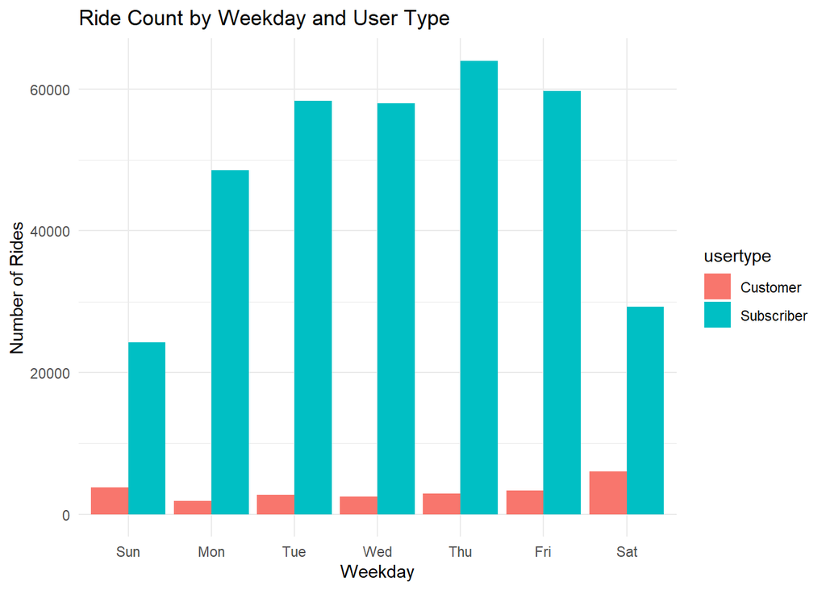

```r
# Ride Count by Weekday and User Type

ggplot(rides_by_weekday_2019, aes(x = weekday, y = ride_count, fill = usertype)) +
  geom_bar(stat = "identity", position = "dodge") +
  labs(title = "Ride Count by Weekday and User Type",
       x = "Weekday", y = "Number of Rides") +
  theme_minimal()
```

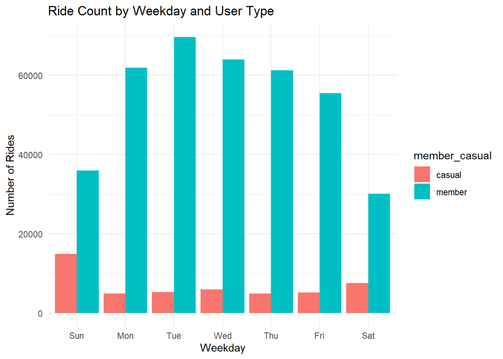

```r
ggplot(rides_by_weekday_2020, aes(x = weekday, y = ride_count, fill = member_casual)) +
  geom_bar(stat = "identity", position = "dodge") +
  labs(title = "Ride Count by Weekday and User Type",
       x = "Weekday", y = "Number of Rides") +
  theme_minimal()
```

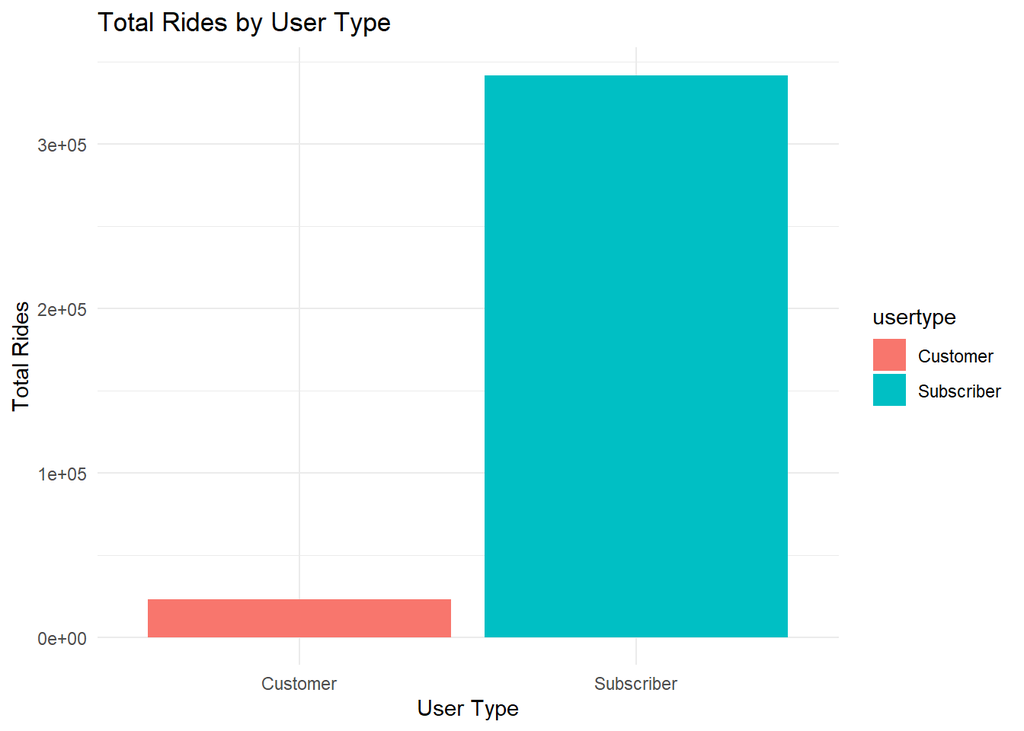

```r
# Total Rides by User Type

ggplot(total_rides_by_group_2019, aes(x = usertype, y = total_rides, fill = usertype)) +
  geom_bar(stat = "identity") +
  labs(title = "Total Rides by User Type",
       x = "User Type", y = "Total Rides") +
  theme_minimal()
```

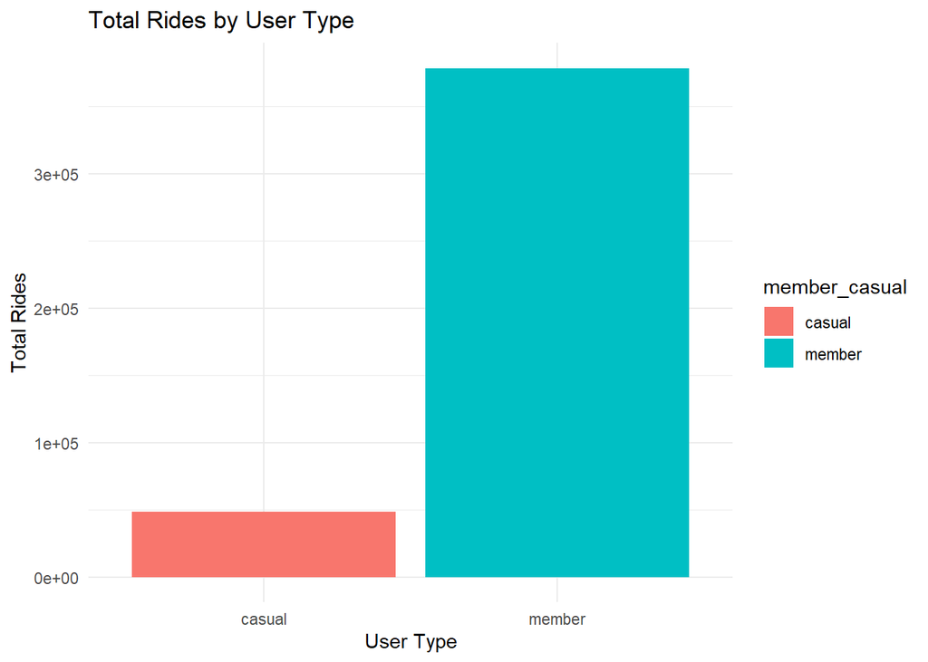

```r
ggplot(total_rides_by_group_2020, aes(x = member_casual, y = total_rides, fill = member_casual)) +
  geom_bar(stat = "identity") +
  labs(title = "Total Rides by User Type",
       x = "User Type", y = "Total Rides") +
  theme_minimal()
```

Question Two:

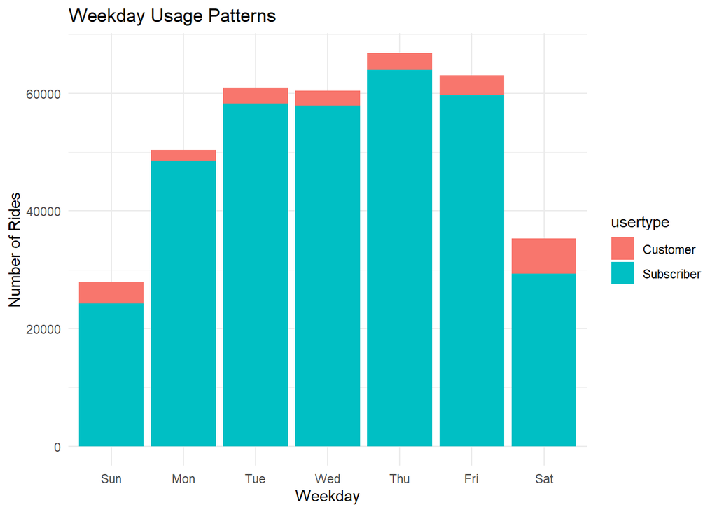

```r
# Weekday Usage by User Type

ggplot(rides_by_weekday_2019, aes(x = weekday, y = ride_count, fill = usertype)) +
  geom_bar(stat = "identity") +
  labs(title = "Weekday Usage Patterns",
       x = "Weekday", y = "Number of Rides") +
  theme_minimal()
```

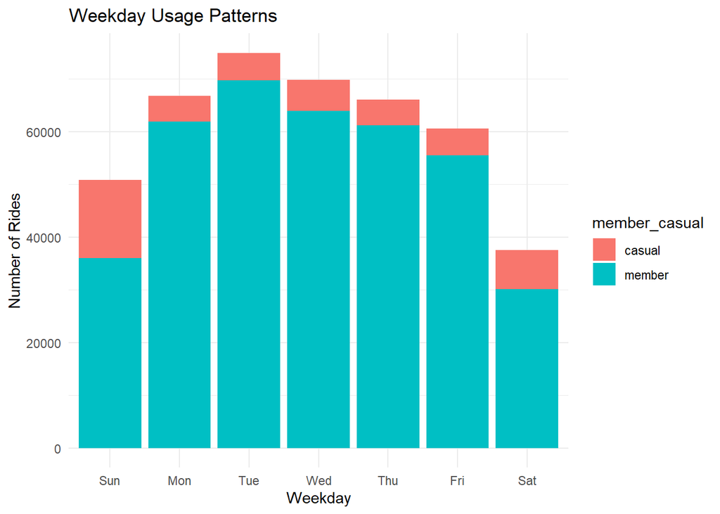

```r
ggplot(rides_by_weekday_2020, aes(x = weekday, y = ride_count, fill = member_casual)) +
  geom_bar(stat = "identity") +
  labs(title = "Weekday Usage Patterns",
       x = "Weekday", y = "Number of Rides") +
  theme_minimal()
```

Question 3:

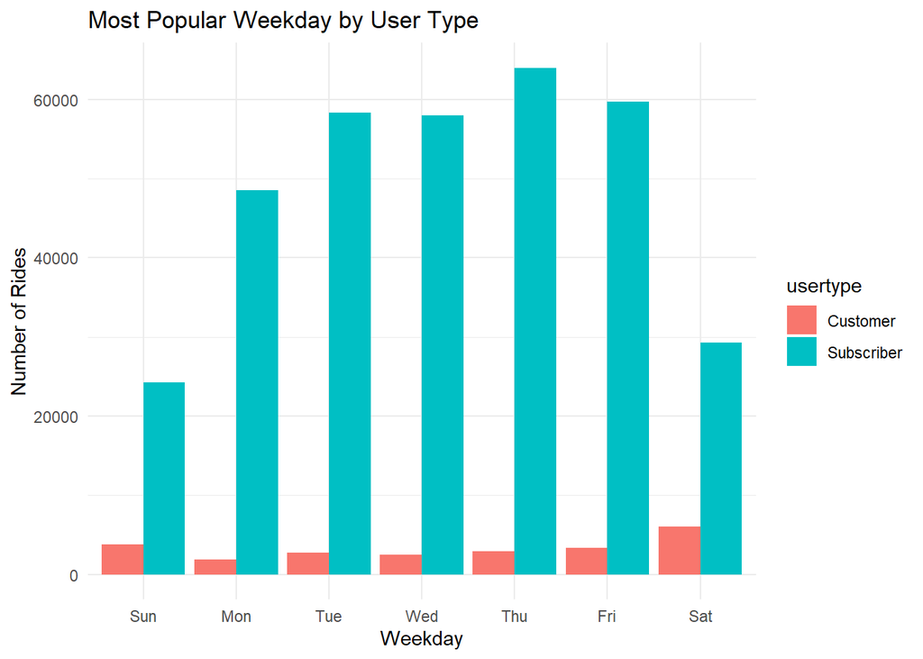

```r
# Most Popular Weekday by User Type

ggplot(rides_by_weekday_2019, aes(x = weekday, y = ride_count, fill = usertype)) +
  geom_bar(stat = "identity", position = "dodge") +
  labs(title = "Most Popular Weekday by User Type",
       x = "Weekday", y = "Number of Rides") +
  theme_minimal()
```

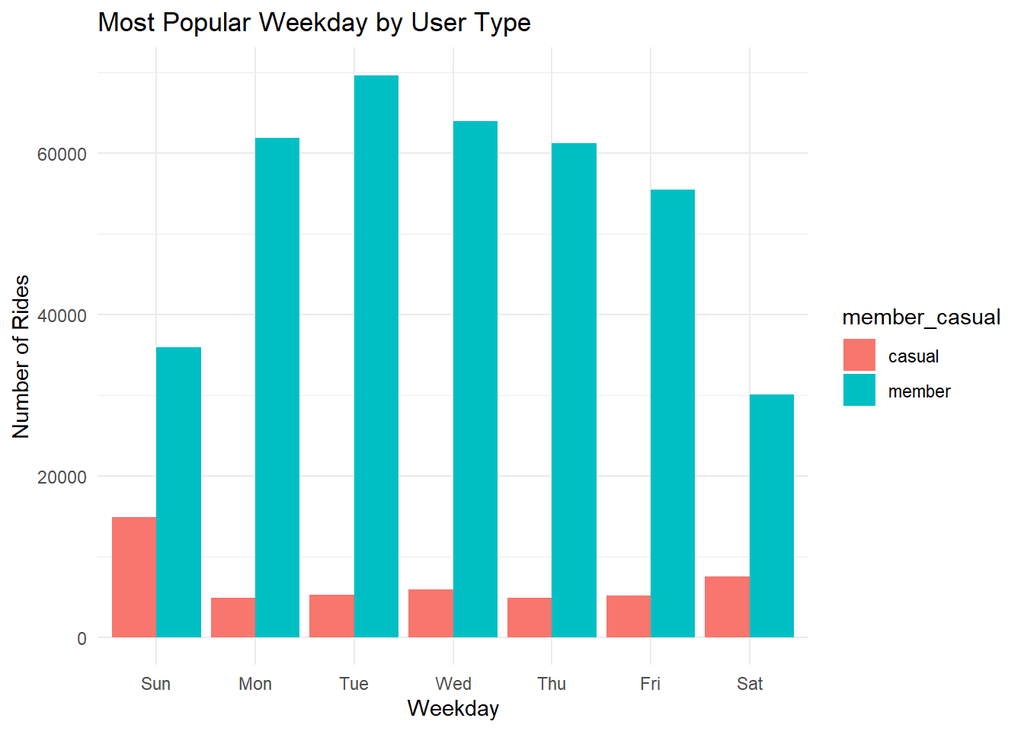

```r
ggplot(rides_by_weekday_2020, aes(x = weekday, y = ride_count, fill = member_casual)) +
  geom_bar(stat = "identity", position = "dodge") +
  labs(title = "Most Popular Weekday by User Type",
       x = "Weekday", y = "Number of Rides") +
  theme_minimal()
```

## Why would casual riders buy a Cyclistic annual membership?

1. Cost Saving: They need to understand and easily see how much they are saving by subscribing to an annual membership. Ccreating new plans for different usage types also helps them choose what's best.
2. Usage Patterns: We must show how convenient it is to be part of the program and how helpful it would be to have the service using motives current annual members have subscribed to help create a connection with the client.
3. Upfront Cost: sometimes upfront costs may scare the client. Free trials or a cheaper starting subscription may help.